# Have You Missed Your Moment to Make a Masterpiece?

### By: Erika Darden

# Introduction

For artists of any age, making it into a major gallery like the Modern Museum of Art (MoMA) is an incredible feat. But how old were these talented artists when they made their first work of art that landed them there? And does where they were born affect this age?

#### Background

For more information, the dataset is available here: https://github.com/MuseumofModernArt/collection

To view other ways people have used the data visit: https://medium.com/@foe/here-s-a-roundup-of-how-people-have-used-our-data-so-far-80862e4ce220

Many works in the collection can be viewed here: https://www.moma.org/collection/

#### Hypothesis

I believe where someone is born greatly influences their relationship with art. I would think that those surrounded by more art would have a headstart on creating their own masterpieces.Therefore, I hypothesize that where an artist was born does have an effect on the age in which they create a work of art good enough to be in MoMA.

## Data Wrangling

#### Curation

First, we must load the datasets downloaded from the link provided above.

```r
library(tidyverse)
library(dplyr)
library(ggplot2)
artist_data <- read_csv("artists.csv")
artwork_data <- read_csv("artworks.csv")

artist_data
```

```
## # A tibble: 15,091 x 6
##    `Artist ID` Name           Nationality Gender `Birth Year` `Death Year`
##          <int> <chr>          <chr>       <chr>         <int>        <int>
##  1           1 Robert Arneson American    Male           1930         1992
##  2           2 Doroteo Arnaiz Spanish     Male           1936           NA
##  3           3 Bill Arnold    American    Male           1941           NA
##  4           4 Charles Arnol… American    Male           1946           NA
##  5           5 Per Arnoldi    Danish      Male           1941           NA
##  6           6 Danilo Aroldi  Italian     Male           1925           NA
##  7           7 Bill Aron      American    Male           1941           NA
##  8           9 David Aronson  American    Male           1923           NA
##  9          10 Irene Aronson  American    Female         1918           NA
## 10          11 Jean (Hans) A… French      Male           1886         1966
## # ... with 15,081 more rows
```

```r
artwork_data
```

```
## # A tibble: 130,262 x 21
##    `Artwork ID` Title       `Artist ID` Name    Date  Medium   Dimensions
##           <int> <chr>       <chr>       <chr>   <chr> <chr>    <chr>
##  1            2 Ferdinands… 6210        Otto W… 1896  Ink and… "19 1/8 x …
##  2            3 City of Mu… 7470        Christ… 1987  Paint a… "16 x 11 3…
##  3            4 Villa near… 7605        Emil H… 1903  Graphit… "13 1/2 x …
##  4            5 The Manhat… 7056        Bernar… 1980  Photogr… "20 x 20\"…
##  5            6 Villa, pro… 7605        Emil H… 1903  Graphit… "15 1/8 x …
##  6            7 The Manhat… 7056        Bernar… 1976… Gelatin… "14 x 18\"…
##  7            8 The Manhat… 7056        Bernar… 1976… Gelatin… "Each: 14 …
##  8            9 The Manhat… 7056        Bernar… 1976… Gelatin… "14 x 18\"…
##  9           10 The Manhat… 7056        Bernar… 1976… Gelatin… "14 x 18\"…
## 10           11 The Manhat… 7056        Bernar… 1976… Gelatin… "14 x 18\"…
## # ... with 130,252 more rows, and 14 more variables: `Acquisition
## #   Date` <date>, Credit <chr>, Catalogue <chr>, Department <chr>,
## #   Classification <chr>, `Object Number` <chr>, `Diameter (cm)` <dbl>,
## #   `Circumference (cm)` <chr>, `Height (cm)` <dbl>, `Length (cm)` <chr>,
## #   `Width (cm)` <dbl>, `Depth (cm)` <dbl>, `Weight (kg)` <dbl>, `Duration
## #   (s)` <chr>
```

#### Tidy the data

To begin tidying the data, first we’ll rename some columns to make them easier to work with. Then we’ll select only the columns we may find useful for this analysis.

```r
artwork_data <- rename(artwork_data, Artwork_ID=`Artwork ID`, Artist_ID=`Artist ID`, Acquisition_Date = `Acquisition Date`)

artist_data <- rename(artist_data, Birth_Year=`Birth Year`, Artist_ID=`Artist ID`)

artwork_data <- artwork_data %>%
  select(Artwork_ID, Title, Artist_ID, Name, Date, Acquisition_Date)
```

For this analysis, let’s only look artworks done by a single artist. We will remove works with multiple artists from artwork_data. In the data, works with multiple artists have multiple artist IDs separated by a comma (“,”). We use a regular expression to filter out entities with a comma in `Artist_ID`.

```r
artwork_data <- artwork_data %>%
  filter(!str_detect(Artist_ID, ".*,.*"))
```

Now, let’s remove any artists with unknown birth years from `artist_data`.

```r
artist_data <- artist_data %>%
  filter(!is.na(Birth_Year))
```

When first viewing the data I could see that the `Date` column was very untidy and would require some cleaning up. Let’s see what kinds of entries will require modification by filtering out correctly formatted years.

```r
artwork_data_bad <- artwork_data %>%
  filter(!str_detect(`Date`, "^\\d{4}$")) %>%
  select(Date)

sample_frac(artwork_data_bad, .1)
```

```
## # A tibble: 4,406 x 1
##    Date
##    <chr>
##  1 c. 1900
##  2 1896-1938
##  3 1920-25
##  4 after 1920?
##  5 c. 1967
##  6 (1968-69)
##  7 c. 1940
##  8 1952-68
##  9 1947-1958
## 10 1937-1938
## # ... with 4,396 more rows
```

It looks like many `Date` entries include ranges and other various notations. We will again use regular expressions to isolate a year and clean up these entries. Afterward we will remove any remaining `NA` entries. Then we’ll change the column type of `Date` from `character` to `integer`.

```r
artwork_data$Date <- str_extract(artwork_data$Date, "\\d{4}")

artwork_data <- artwork_data %>%
  filter(!is.na(Date))

artwork_data <- artwork_data %>%
  type_convert(cols_only(Artist_Id = col_integer(), Title = col_character(), Artist_ID = col_integer(), Name = col_character(), Date = col_integer(), Acquisition_Date = col_date(format = "%Y-%m-%d")))
```

Next, we’ll find the date of the earliest artwork created by each artist and add that to `artist_data` and remove any resulting entities with NA. Then we’ll calculate the artists’ age at the time of creation. To account for any error we’ll filter out any ages less than or equal to ten or greater than 100.

```r
earliest_work <- artwork_data %>%
  group_by(Artist_ID) %>%
  summarise(min_date=min(Date))

artist_data <- artist_data %>%
  left_join(earliest_work, by="Artist_ID")

artist_data <- artist_data %>%
  filter(!is.na(min_date) & !(is.na(Nationality)))

artist_data$age <- (artist_data$min_date - artist_data$Birth_Year)

artist_data <- artist_data %>%
  filter(age > 10 & age < 100)
```

Here we can see that there are 117 different nationalities of artists. For this analysis we’ll just use the top 15 nations with the most artists.

```r
unique(artist_data$Nationality)
```

```
##   [1] "American"            "Danish"              "French"
##   [4] "Estonian"            "Swedish"             "Spanish"
##   [7] "British"             "Italian"             "Finnish"
##  [10] "Polish"              "Japanese"            "Guatemalan"
##  [13] "Colombian"           "Romanian"            "Israeli"
##  [16] "German"              "Argentine"           "Kuwaiti"
##  [19] "Belgian"             "Dutch"               "Mexican"
##  [22] "Norwegian"           "Chilean"             "Swiss"
##  [25] "Costa Rican"         "Czech"               "Brazilian"
##  [28] "Austrian"            "Canadian"            "Russian"
##  [31] "Australian"          "Ukrainian"           "Hungarian"
##  [34] "Haitian"             "Congolese"           "Bolivian"
##  [37] "Cuban"               "Yugoslav"            "Portuguese"
##  [40] "Indian"              "Nationality unknown" "Irish"
##  [43] "Guyanese"            "Uruguayan"           "Croatian"
```

[output cut: 24 more lines]

```r
most_nationalities <- artist_data %>%
  group_by(Nationality) %>%
  summarise(count = n()) %>%
  top_n(15)

most_nationalities
```

```
## # A tibble: 15 x 2
##    Nationality count
##    <chr>       <int>
##  1 American     3973
##  2 Argentine      99
##  3 Austrian      162
##  4 Brazilian     126
##  5 British       538
##  6 Canadian      145
##  7 Dutch         162
##  8 French        632
##  9 German        669
## 10 Italian       317
## 11 Japanese      333
## 12 Polish        103
## 13 Russian       134
## 14 Spanish       102
## 15 Swiss         188
```

Now we’ll filter out all artists who are not from one of the top 15 nations.

```r
top_artist_data <- artist_data %>%
  filter(Nationality %in% c("American","Austrian","British","Canadian", "Dutch", "French", "German", "Italian", "Japanese", "Swiss", "Argentine", "Brazilian", "Polish", "Russian", "Spanish"))
```

## Exploratory Data Analysis

Notice the average age of artists over the top 15 nations is 35.57, close to the total average of 35.64. However, it is possible that America is overrepresented in this dataset. Interestingly, by removing America the average age over all nations is 35.86 and over the top 14 is 35.78. However, the differences aren’t drastic enough to say America skews the data in any significant way.

```r
mean(artist_data$age)
```

```
## [1] 35.64312
```

```r
mean(top_artist_data$age)
```

```
## [1] 35.56853
```

```r
na_artist_data <- artist_data %>%
  filter(Nationality != "American")

mean(na_artist_data$age)
```

```
## [1] 35.86044
```

```r
na_top_artist_data <- top_artist_data %>%
  filter(Nationality != "American")

mean(na_top_artist_data$age)
```

```
## [1] 35.78329
```

In the boxplot below we can see the average age of artists from each nation as well as the spread of ages and inner quartile ranges. The plot shows that the average age of artists from each nation are very close.

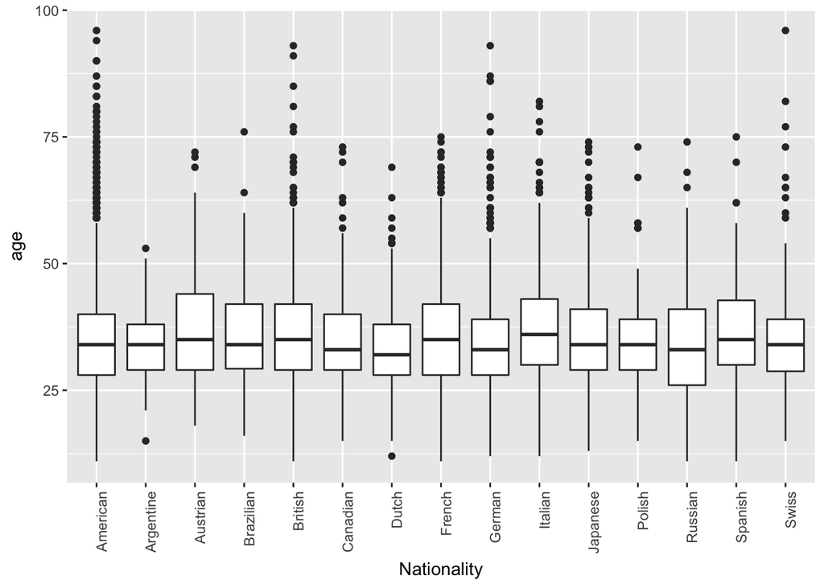

```r
top_artist_data %>%
  group_by(Nationality) %>%
  ggplot(mapping=aes(x=Nationality, y=age)) +
  geom_boxplot() +
  theme(axis.text.x = element_text(angle = 90, hjust = 1))
```

```r
art_fit <- lm(age~Nationality, data=top_artist_data)
art_fit_stats <- art_fit %>%
  broom::tidy()
art_fit_stats
```

```
##                    term    estimate std.error    statistic      p.value
## 1           (Intercept) 35.36798389 0.1719036 205.74314332 0.000000e+00
## 2  NationalityArgentine -1.63061015 1.1024813  -1.47903660 1.391716e-01
## 3   NationalityAustrian  1.47152228 0.8684907   1.69434427 9.024049e-02
## 4  NationalityBrazilian  0.18757166 0.9804797   0.19130601 8.482909e-01
## 5    NationalityBritish  1.03350310 0.4977717   2.07625922 3.790322e-02
## 6   NationalityCanadian -0.16108734 0.9161026  -0.17583985 8.604244e-01
## 7      NationalityDutch -1.26304562 0.8684907  -1.45429950 1.459042e-01
## 8     NationalityFrench  0.77283889 0.4640248   1.66551197 9.585151e-02
## 9     NationalityGerman -0.51148165 0.4528188  -1.12955040 2.587011e-01
## 10   NationalityItalian  2.53422431 0.6323885   4.00738533 6.197579e-05
## 11  NationalityJapanese  0.37676085 0.6181585   0.60948910 5.422184e-01
## 12    NationalityPolish  0.05920057 1.0813926   0.05474475 9.563432e-01
## 13   NationalityRussian -0.84559583 0.9516886  -0.88852151 3.742882e-01
## 14   NationalitySpanish  1.48495729 1.0865473   1.36667518 1.717672e-01
## 15     NationalitySwiss -0.03819666 0.8087324  -0.04723028 9.623309e-01
```

The violin plot below shows that most residuals are concentrated below zero indicating that there is a higher concentration of ages below the estimate but the outliers above zero are extreme enough to bring raise the estimate. Because of this, the results may be skewed.

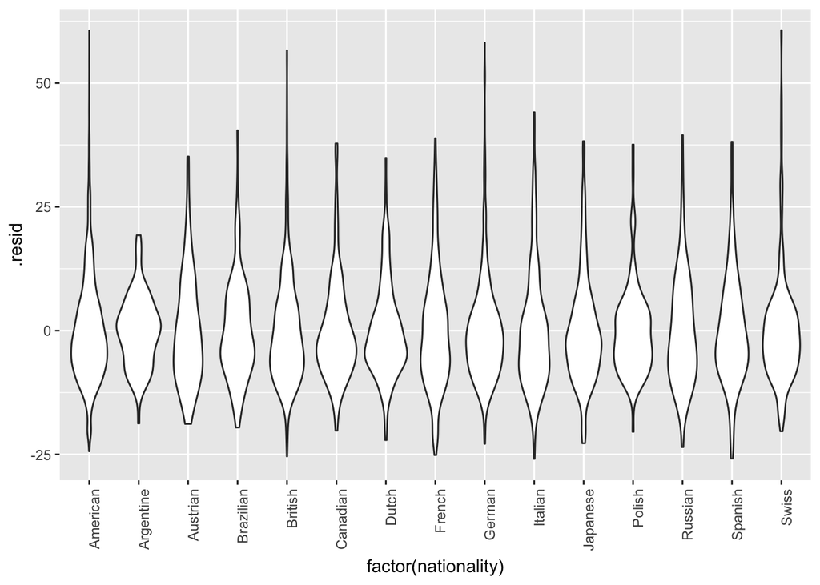

```r
augmented_art <- art_fit %>%
  broom::augment()

augmented_art <- augmented_art %>%
  mutate(nationality=top_artist_data$Nationality)

augmented_art %>%
  ggplot(mapping = aes(x=factor(nationality), y = .resid)) +
  geom_violin() +
  theme(axis.text.x = element_text(angle = 90, hjust = 1))
```